# Tarea 2

Eugenio Ortega, Camilo Riquelme

2022-05-24

## Presentación de la base

La base utilizada, corresponde a la base de datos de la Encuesta Nacional de Empleo del año 2021, realizada por el INE. En especifico el trimestre de junio, julio y agosto del mismo año. El INE (2021) define esta encuesta como: *Un instrumento que nos permite conocer la situación de trabajo que tienen las personas que viven en Chile.*

En particular para esta investigación se utilizaron las siguentes variables:

1. Sexo
2. Edad
3. Cine - Clasificación Internacional Normalizada de la Educación.
4. e23 - ¿Cúal fue el motivo de su despido?
5. e22- ¿Por qué razón ya no tiene ese empleo, negocio o actividad por cuenta propia?
6. b14_rev4cl_caenes - Rama de actividad económica de empresa donde trabaja según CAENES
7. c9_otro_covid - Respuesta asociada a pandemia COVID-19 en c9_otro, referencia c9, ¿Cuál fue la principal razón por la cual trabajó un número de horas diferente a lo habitual durante la semana pasada en su actividad principal?
8. e12_otro_covid - Respuesta asociada a pandemia COVID-19 en e12_otro, referencia e12, ¿Por qué motivo no estaría disponible para trabajar?

## Paquetes Utilizados

```r
pacman::p_load(haven, tidyverse, sjmisc, sjPlot, kableExtra)
```

## Análisis descriptivo univariado: Sexo - Edad - Nivel Educacional

Distribución de sexo/edad en tramos/nivel educacional

| Valor | Etiqueta | F. absoluta | F. relativa | F. relativa (valida) | F. rel. acumulada |
| --- | --- | --- | --- | --- | --- |
| Hombre | <none> | 36064 | 45.59 | 45.59 | 45.59 |
| Mujer | <none> | 43044 | 54.41 | 54.41 | 100.00 |

| Valor | Etiqueta | F. absoluta | F. relativa | F. relativa (valida) | F. rel. acumulada |
| --- | --- | --- | --- | --- | --- |
| 60+ | <none> | 23537 | 29.75 | 29.75 | 29.75 |
| 40 a 59 años | <none> | 26711 | 33.77 | 33.77 | 63.52 |
| 18 a 39 años | <none> | 28860 | 36.48 | 36.48 | 100.00 |

| Valor | Etiqueta | F. absoluta | F. relativa | F. relativa (valida) | F. rel. acumulada |
| --- | --- | --- | --- | --- | --- |
| Basica o menos incompleta | <none> | 12269 | 15.51 | 15.62 | 15.62 |
| Superior completa | <none> | 24516 | 30.99 | 31.20 | 46.82 |
| Media y basica completa | <none> | 41780 | 52.81 | 53.18 | 100.00 |

Fuente:

Elaboración propia en base a ENE jun-ago (2021)

### Comparación Censo2017

Si comparamos los resultados obtenidos, respecto del Censo2017 vemos que:

En cuanto a la distrubución de sexo, el Censo reporta que un 48,9% de la población son hombres y un 51.1% mujeres.

Se muestra una diferencia de 3.31% en ambos sexos, respecto de la muestra.

En cuanto a los tramos de edad, la estadistica a relevar, corresponde a los tramos de mayor edad, donde se refuerza el envejecimiento de la población chilena, el Censo2017 reporta que solo un 6,6% de la población, para esa fecha, tenia más de 65 años. Los resultados de nuestra base de datos, a pesar de ser un tramo de edad más amplio, demuestran un evidente envejecimiento de la población, un 29.75% de la muestra posee más de 60 años.

*Fuente: Sintesís de resultados Censo 2017*

## Análisis descriptivo univariado: Ocupaciones

```r
JJA_proc %>%
  select(activ, ocup_form, b1, b14_rev4cl_caenes) %>%
  frq(show.na = F,
      out = "viewer",
      encoding = "UTF-8",
      sort.frq = "asc") %>%
  kable(caption = "Distribución de Ocupaciones",
        format = "html",
        col.names = c("Valor", "Etiqueta", "F. absoluta", "F. relativa",
                      "F. relativa (valida)", "F. rel. acumulada"),
        position = "center") %>%
  kable_classic(full_width = F,
                html_font = "Cambria") %>%
  footnote("Elaboración propia en base a ENE jun-ago (2021)",
           general_title = "Fuente: ")
```

Distribución de Ocupaciones

| Valor | Etiqueta | F. absoluta | F. relativa | F. relativa (valida) | F. rel. acumulada |
| --- | --- | --- | --- | --- | --- |
| Desocupados/as | <none> | 3238 | 4.09 | 4.09 | 4.09 |
| Fuera de la fuerza de trabajo | <none> | 37781 | 47.76 | 47.76 | 51.85 |
| Ocupados/as | <none> | 38089 | 48.15 | 48.15 | 100.00 |

| Valor | Etiqueta | F. absoluta | F. relativa | F. relativa (valida) | F. rel. acumulada |
| --- | --- | --- | --- | --- | --- |
| Sin clasificación | <none> | 0 | 0.00 | 0.0 | 0.0 |
| Ocupado informal | <none> | 11199 | 14.16 | 29.4 | 29.4 |
| Ocupado formal | <none> | 26890 | 33.99 | 70.6 | 100.0 |

| Valor | Etiqueta | F. absoluta | F. relativa | F. relativa (valida) | F. rel. acumulada |
| --- | --- | --- | --- | --- | --- |
| Sin clasificación | <none> | 0 | 0.00 | 0.00 | 0.00 |
| Otros no identificados | <none> | 169 | 0.21 | 0.44 | 0.44 |
| Directores, gerentes y administradores | <none> | 1209 | 1.53 | 3.18 | 3.62 |
| Agricultores y trabajadores calificados agropecuarios, forestales y pesqueros | <none> | 1606 | 2.03 | 4.22 | 7.84 |
| Personal de apoyo administrativo | <none> | 1871 | 2.37 | 4.92 | 12.76 |
| Operadores de instalaciones, maquinas y ensambladores | <none> | 3077 | 3.89 | 8.09 | 20.85 |
| Técnicos y profesionales de nivel medio | <none> | 4360 | 5.51 | 11.46 | 32.31 |
| Profesionales, científicos e intelectuales | <none> | 4783 | 6.05 | 12.57 | 44.88 |
| Artesanos y operarios de oficios | <none> | 5111 | 6.46 | 13.43 | 58.32 |
| Ocupaciones elementales | <none> | 7914 | 10.00 | 20.80 | 79.12 |
| Trabajadores de los servicios y vendedores de comercios y mercados | <none> | 7944 | 10.04 | 20.88 | 100.00 |

| Valor | Etiqueta | F. absoluta | F. relativa | F. relativa (valida) | F. rel. acumulada |
| --- | --- | --- | --- | --- | --- |
| Actividades de organizaciones y órganos extraterritoriales | <none> | 0 | 0.00 | 0.00 | 0.00 |
| Sin clasificación | <none> | 0 | 0.00 | 0.00 | 0.00 |
| Suministro de electricidad, gas, vapor y aire acondicionado | <none> | 191 | 0.24 | 0.50 | 0.50 |
| Actividades artísticas, de entretenimiento y recreativas | <none> | 251 | 0.32 | 0.66 | 1.16 |
| Actividades inmobiliarias | <none> | 302 | 0.38 | 0.79 | 1.96 |
| Suministro de agua | <none> | 316 | 0.40 | 0.83 | 2.79 |
| Actividades financieras y de seguros | <none> | 506 | 0.64 | 1.33 | 4.12 |
| Información y comunicaciones | <none> | 555 | 0.70 | 1.46 | 5.58 |
| Actividades de servicios administrativos y de apoyo | <none> | 921 | 1.16 | 2.42 | 8.00 |
| Actividades profesionales, científicas y técnicas | <none> | 1024 | 1.29 | 2.69 | 10.70 |
| Otras actividades de servicios | <none> | 1099 | 1.39 | 2.89 | 13.59 |
| Explotación de minas y canteras | <none> | 1250 | 1.58 | 3.29 | 16.88 |
| Actividades de los hogares como empleadores | <none> | 1304 | 1.65 | 3.43 | 20.31 |
| Actividades de alojamiento y de servicio de comidas | <none> | 1481 | 1.87 | 3.90 | 24.20 |
| Transporte y almacenamiento | <none> | 2224 | 2.81 | 5.85 | 30.05 |
| Actividades de atención de la salud humana y de asistencia social | <none> | 2410 | 3.05 | 6.34 | 36.39 |
| Administración pública y defensa | <none> | 2627 | 3.32 | 6.91 | 43.30 |
| Construcción | <none> | 3330 | 4.21 | 8.76 | 52.06 |
| Enseñanza | <none> | 3547 | 4.48 | 9.33 | 61.39 |
| Industrias manufactureras | <none> | 3760 | 4.75 | 9.89 | 71.29 |
| Agricultura, ganadería, silvicultura y pesca | <none> | 3959 | 5.00 | 10.41 | 81.70 |
| Comercio al por mayor y al por menor | <none> | 6956 | 8.79 | 18.30 | 100.00 |

Fuente:

Elaboración propia en base a ENE jun-ago (2021)

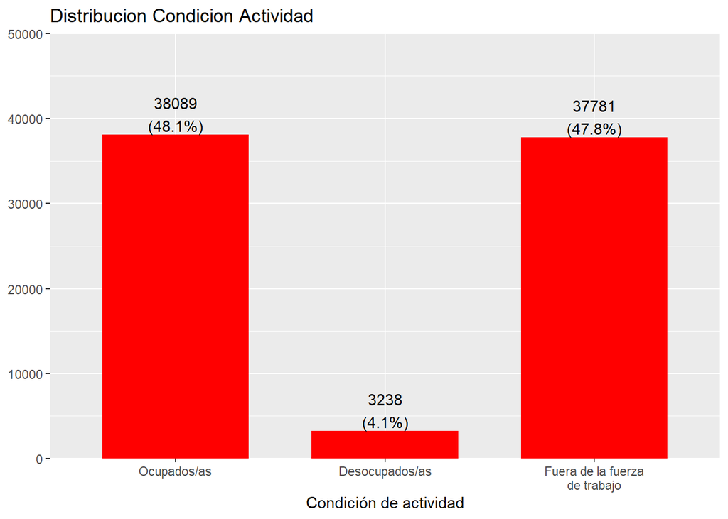

```r
#Graficos sobre Ocupaciones

plot_frq(JJA_proc, activ,
         geom.colors = "red",
         title = "Distribucion Condicion Actividad",
         type = "bar")
```

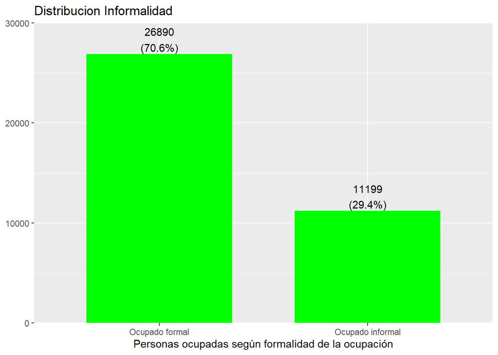

```r
plot_frq(JJA_proc, ocup_form,
         geom.colors = "green",
         title = "Distribucion Informalidad",
         type = "bar")
```

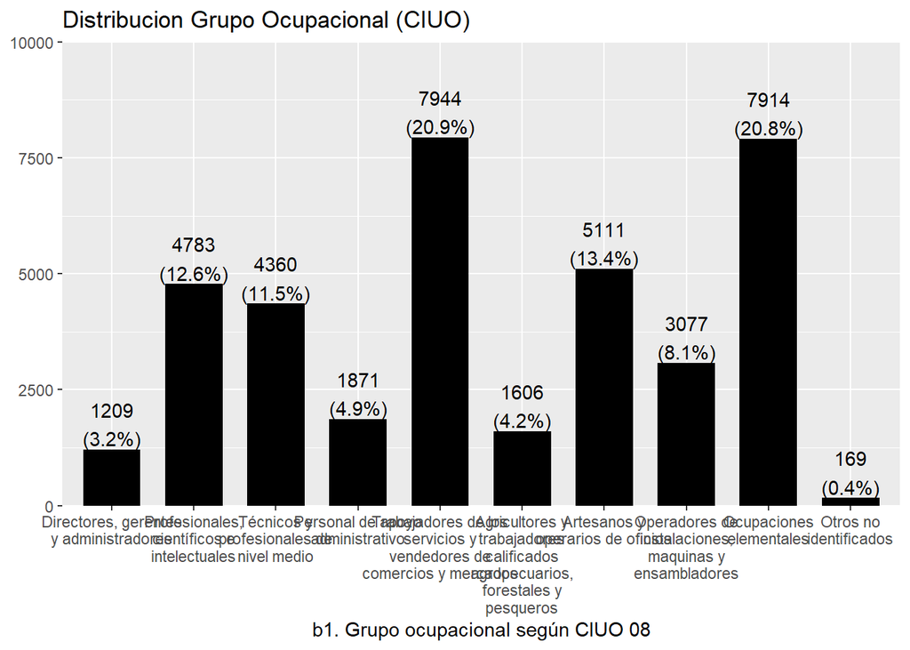

```r
plot_frq(JJA_proc, b1,
         geom.colors = "black",
         title = "Distribucion Grupo Ocupacional (CIUO)",
         type = "bar")
```

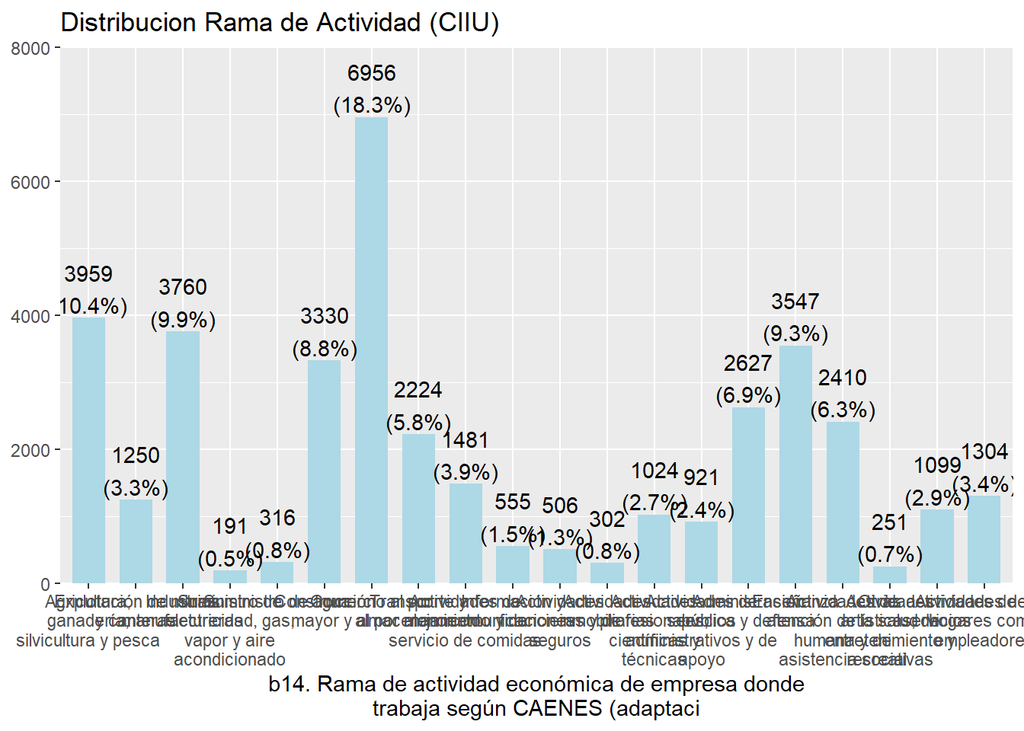

```r
plot_frq(JJA_proc, b14_rev4cl_caenes,
         geom.colors = "lightblue",
         title = "Distribucion Rama de Actividad (CIIU)",
         type = "bar")
```

Al analizar la distribución por condición de actividad, vemos que un 48,1% de la muestra se encuentra ocupada, un 4,1% de desempleo y un 47,8% de la muestra no está buscando empleo, ni tiene interés de trabajar, reduciendo interés de trabajo en busqueda de empleo.

Analizando el grafico de distribución de informalidad, vemos que casi un 30% (29,4) de la muestra, está en condición de informalidad, es decir son trabajadores independientes o por sus condiciones laborales se encuentran fuera de las regulaciones del derecho de trabajo. Por el contrario un 70,6% de la muestra manifiesta estar en condiciones de ocupado formal.

## Análisis descriptivo univariado: Covid19

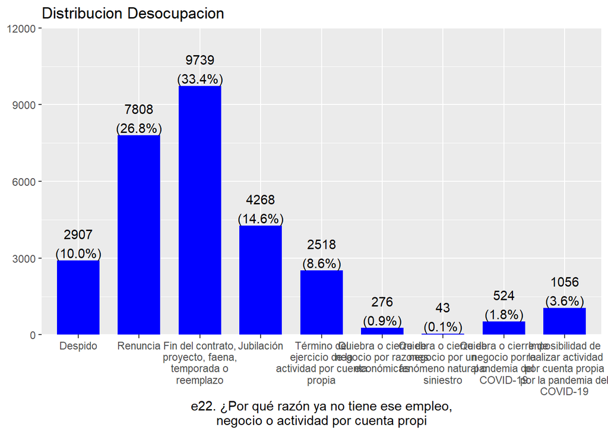

```r
plot_frq(JJA_proc, e22,
         geom.colors = "blue",
         title = "Distribucion Desocupacion",
         type = "bar")
```

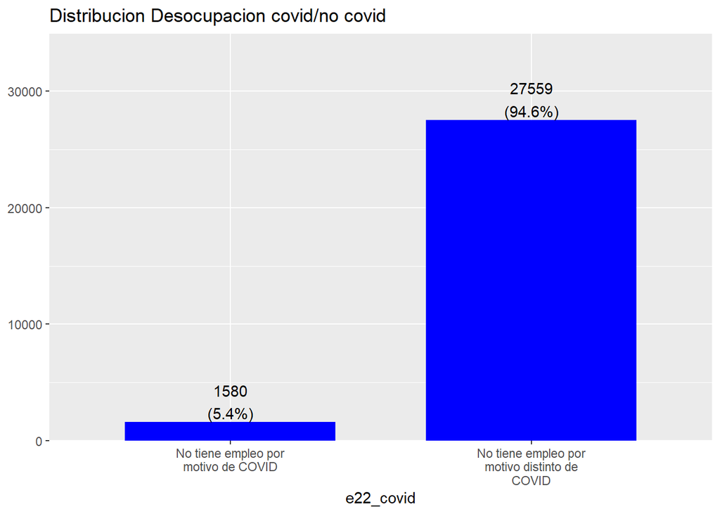

```r
plot_frq(JJA_proc, e22_covid,
         geom.colors = "blue",
         title = "Distribucion Desocupacion covid/no covid",
         type = "bar")
```

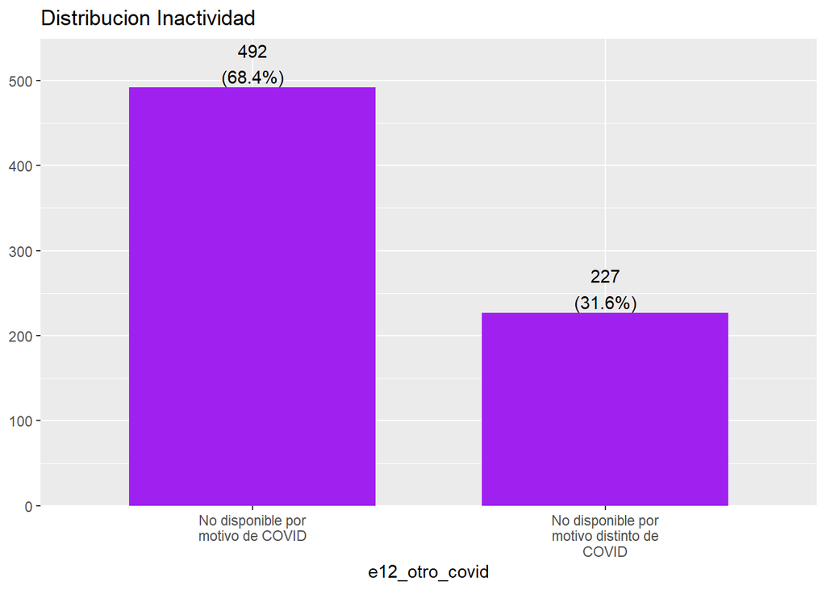

```r
plot_frq(JJA_proc, e12_otro_covid,
         geom.colors = "purple",
         title = "Distribucion Inactividad",
         type = "bar")
```

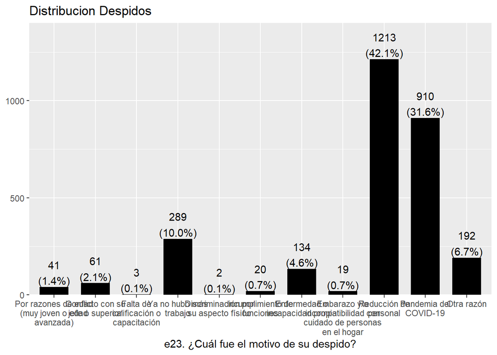

```r
plot_frq(JJA_proc, e23,
         geom.colors = "black",
         title = "Distribucion Despidos",
         type = "bar")
```

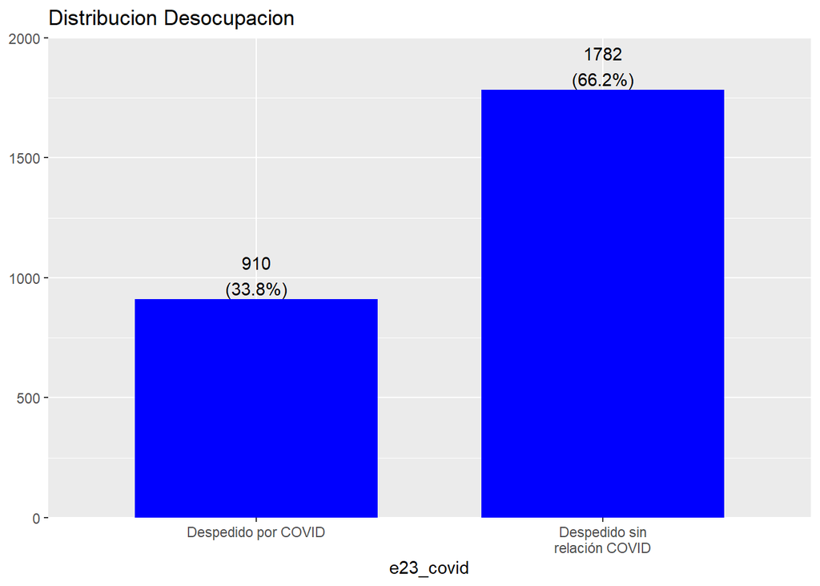

```r
plot_frq(JJA_proc, e23_covid,
         geom.colors = "blue",
         title = "Distribucion Desocupacion",
         type = "bar")
```

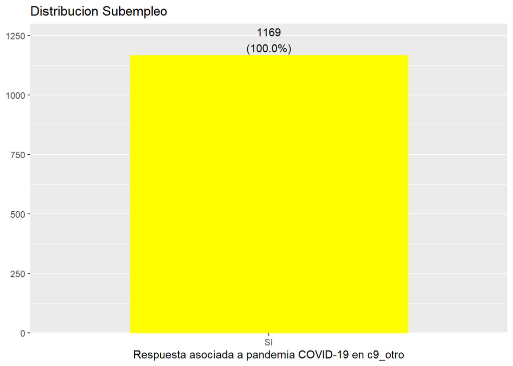

```r
plot_frq(JJA_proc, c9_otro_covid,
         geom.colors = "yellow",
         title = "Distribucion Subempleo",
         type = "bar")
```

Al analizar las graficas correspondientes a variables, relacionadas por la pandemia Covid19, los datos que más sorprenden corresponden a la cantidad de personas que manifiestan haber sido despedidas por motivos relacionados al Covid19, un 33,8%, lo que tienen estrecha relación con la alta tasa de desempleo que provoco la pandemia. El otro dato importante hace referencia a las personas que manifiestan no estar disponibles para trabajar, producto del Covid19 alcanzando un 68,4%, del total de persona no disponibles para trabajar.

## Análisis descriptivo bivariado Covid19

```r
#Edad por categoria Informalidad y Tipo de Jornada

sjt.xtab(JJA_proc$edad_tr, JJA_proc$ocup_form,
         show.col.prc=TRUE,
         show.row.prc=TRUE,
         show.summary=FALSE,
         encoding = "UTF-8",
         title = "Tabla Edad segun Informalidad")
```

Tabla Edad segun Informalidad

| edad_tr | Personas ocupadas según formalidad de la ocupación |  |  | Total |  |
| --- | --- | --- | --- | --- | --- |
|  | Ocupado formal | Ocupado informal | Sin clasificación |  |  |
| 18 a 39 años | 10858 72.6 % 40.4 % | 4090 27.4 % 36.5 % | 0 0 % 0 % |  | 14948 100 % 39.2 % |
| 40 a 59 años | 12455 72.7 % 46.3 % | 4684 27.3 % 41.8 % | 0 0 % 0 % | 17139 100 % 45 % |  |
| 60+ | 3577 59.6 % 13.3 % | 2425 40.4 % 21.7 % | 0 0 % 0 % | 6002 100 % 15.8 % |  |
| Total | 26890 70.6 % 100 % | 11199 29.4 % 100 % | 0 0 % 100 % | 38089 100 % 100 % |  |

```r
sjt.xtab(JJA_proc$edad_tr, JJA_proc$c2_1_3,
         show.col.prc=TRUE,
         show.row.prc=TRUE,
         show.summary=FALSE,
         encoding = "UTF-8",
         title = "Tabla Edad segun Tipo de Jornada")
```

Tabla Edad segun Tipo de Jornada

| edad_tr | c2_1_3 |  | Total |  |
| --- | --- | --- | --- | --- |
|  | Jornada Completa | Jornada Parcial |  |  |
| 18 a 39 años | 9959 77.1 % 41.2 % | 2964 22.9 % 36.8 % |  | 12923 100 % 40.1 % |
| 40 a 59 años | 11015 76.5 % 45.6 % | 3379 23.5 % 42 % | 14394 100 % 44.7 % |  |
| 60+ | 3182 65.1 % 13.2 % | 1707 34.9 % 21.2 % | 4889 100 % 15.2 % |  |
| Total | 24156 75 % 100 % | 8050 25 % 100 % | 32206 100 % 100 % |  |

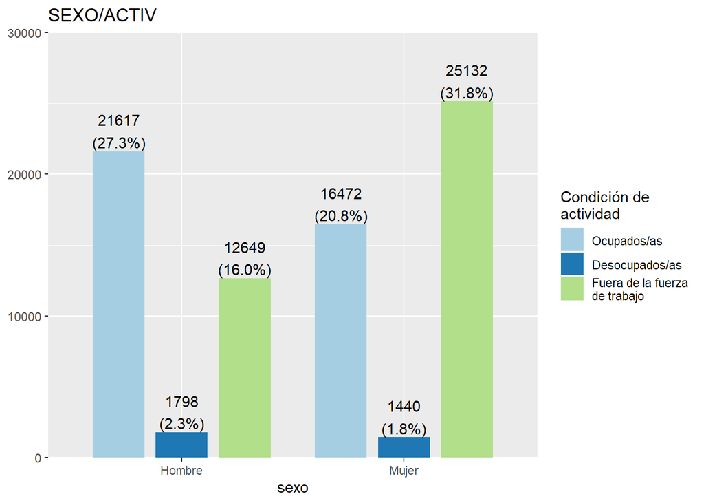

```r
#Activ segun sexo
plot_grpfrq(JJA_proc$sexo, JJA_proc$activ,
            type = "bar", title = "SEXO/ACTIV")
```

[figure not shown]

```r
################################################################################
#Grupo Ocupacional y Razones de Desocupacion **************

plot_grpfrq(JJA_proc$b1, JJA_proc$e22_covid, #SIN NA
            type = "bar", title = "Grupo ocupacional y Razones de despido")
```

```r
table(JJA_proc$b1, JJA_proc$e22_covid) #SIN NA
```

```
##
##                                                                                 No tiene empleo por motivo de COVID
##   Directores, gerentes y administradores                                                                          0
##   Profesionales, científicos e intelectuales                                                                      0
##   Técnicos y profesionales de nivel medio                                                                         0
##   Personal de apoyo administrativo                                                                                0
##   Trabajadores de los servicios y vendedores de comercios y mercados                                              0
##   Agricultores y trabajadores calificados agropecuarios, forestales y pesqueros                                   0
##   Artesanos y operarios de oficios                                                                                0
##   Operadores de instalaciones, maquinas y ensambladores                                                           0
##   Ocupaciones elementales                                                                                         0
##   Otros no identificados                                                                                          0
##   Sin clasificación                                                                                               0
##
##                                                                                 No tiene empleo por motivo distinto de COVID
##   Directores, gerentes y administradores                                                                                   0
##   Profesionales, científicos e intelectuales                                                                               0
##   Técnicos y profesionales de nivel medio                                                                                  0
##   Personal de apoyo administrativo                                                                                         0
##   Trabajadores de los servicios y vendedores de comercios y mercados                                                       0
##   Agricultores y trabajadores calificados agropecuarios, forestales y pesqueros                                            0
##   Artesanos y operarios de oficios                                                                                         0
##   Operadores de instalaciones, maquinas y ensambladores                                                                    0
##   Ocupaciones elementales                                                                                                  0
##   Otros no identificados                                                                                                   0
##   Sin clasificación                                                                                                        0
```

```r
table(JJA_proc$b1, JJA_proc$e22_covid, exclude=F) #CON NA
```

```
##
##                                                                                 No tiene empleo por motivo de COVID
##   Directores, gerentes y administradores                                                                          0
##   Profesionales, científicos e intelectuales                                                                      0
##   Técnicos y profesionales de nivel medio                                                                         0
##   Personal de apoyo administrativo                                                                                0
##   Trabajadores de los servicios y vendedores de comercios y mercados                                              0
##   Agricultores y trabajadores calificados agropecuarios, forestales y pesqueros                                   0
##   Artesanos y operarios de oficios                                                                                0
##   Operadores de instalaciones, maquinas y ensambladores                                                           0
##   Ocupaciones elementales                                                                                         0
##   Otros no identificados                                                                                          0
##   Sin clasificación                                                                                               0
##   <NA>                                                                                                         1580
##
##                                                                                 No tiene empleo por motivo distinto de COVID
##   Directores, gerentes y administradores                                                                                   0
##   Profesionales, científicos e intelectuales                                                                               0
##   Técnicos y profesionales de nivel medio                                                                                  0
##   Personal de apoyo administrativo                                                                                         0
##   Trabajadores de los servicios y vendedores de comercios y mercados                                                       0
##   Agricultores y trabajadores calificados agropecuarios, forestales y pesqueros                                            0
##   Artesanos y operarios de oficios                                                                                         0
##   Operadores de instalaciones, maquinas y ensambladores                                                                    0
##   Ocupaciones elementales                                                                                                  0
##   Otros no identificados                                                                                                   0
##   Sin clasificación                                                                                                        0
##   <NA>                                                                                                                 27559
##
##                                                                                  <NA>
##   Directores, gerentes y administradores                                         1209
##   Profesionales, científicos e intelectuales                                     4783
##   Técnicos y profesionales de nivel medio                                        4360
##   Personal de apoyo administrativo                                               1871
##   Trabajadores de los servicios y vendedores de comercios y mercados             7944
##   Agricultores y trabajadores calificados agropecuarios, forestales y pesqueros  1606
##   Artesanos y operarios de oficios                                               5111
##   Operadores de instalaciones, maquinas y ensambladores                          3077
##   Ocupaciones elementales                                                        7914
##   Otros no identificados                                                          169
##   Sin clasificación                                                                 0
##   <NA>                                                                          11925
```

```r
table(JJA_proc$b1, JJA_proc$e22) #SIN NA
```

```
##
##                                                                                 Despido
##   Directores, gerentes y administradores                                              0
##   Profesionales, científicos e intelectuales                                          0
##   Técnicos y profesionales de nivel medio                                             0
##   Personal de apoyo administrativo                                                    0
##   Trabajadores de los servicios y vendedores de comercios y mercados                  0
##   Agricultores y trabajadores calificados agropecuarios, forestales y pesqueros       0
##   Artesanos y operarios de oficios                                                    0
##   Operadores de instalaciones, maquinas y ensambladores                               0
##   Ocupaciones elementales                                                             0
##   Otros no identificados                                                              0
##   Sin clasificación                                                                   0
##
##                                                                                 Renuncia
##   Directores, gerentes y administradores                                               0
##   Profesionales, científicos e intelectuales                                           0
##   Técnicos y profesionales de nivel medio                                              0
##   Personal de apoyo administrativo                                                     0
##   Trabajadores de los servicios y vendedores de comercios y mercados                   0
##   Agricultores y trabajadores calificados agropecuarios, forestales y pesqueros        0
##   Artesanos y operarios de oficios                                                     0
##   Operadores de instalaciones, maquinas y ensambladores                                0
##   Ocupaciones elementales                                                              0
##   Otros no identificados                                                               0
##   Sin clasificación                                                                    0
##
##                                                                                 Fin del contrato, proyecto, faena, temporada o reemplazo
##   Directores, gerentes y administradores                                                                                               0
##   Profesionales, científicos e intelectuales                                                                                           0
##   Técnicos y profesionales de nivel medio                                                                                              0
##   Personal de apoyo administrativo                                                                                                     0
##   Trabajadores de los servicios y vendedores de comercios y mercados                                                                   0
##   Agricultores y trabajadores calificados agropecuarios, forestales y pesqueros                                                        0
##   Artesanos y operarios de oficios                                                                                                     0
##   Operadores de instalaciones, maquinas y ensambladores                                                                                0
##   Ocupaciones elementales                                                                                                              0
##   Otros no identificados                                                                                                               0
##   Sin clasificación                                                                                                                    0
##
```

[output cut: 88 more lines]

```
##   Otros no identificados                                                              0
##   Sin clasificación                                                                   0
##
##                                                                                 No responde
##   Directores, gerentes y administradores                                                  0
##   Profesionales, científicos e intelectuales                                              0
##   Técnicos y profesionales de nivel medio                                                 0
##   Personal de apoyo administrativo                                                        0
##   Trabajadores de los servicios y vendedores de comercios y mercados                      0
##   Agricultores y trabajadores calificados agropecuarios, forestales y pesqueros           0
##   Artesanos y operarios de oficios                                                        0
##   Operadores de instalaciones, maquinas y ensambladores                                   0
##   Ocupaciones elementales                                                                 0
##   Otros no identificados                                                                  0
##   Sin clasificación                                                                       0
```

```r
table(JJA_proc$b1, JJA_proc$e22, exclude=F) #CON NA
```

```
##
##                                                                                 Despido
##   Directores, gerentes y administradores                                              0
##   Profesionales, científicos e intelectuales                                          0
##   Técnicos y profesionales de nivel medio                                             0
##   Personal de apoyo administrativo                                                    0
##   Trabajadores de los servicios y vendedores de comercios y mercados                  0
##   Agricultores y trabajadores calificados agropecuarios, forestales y pesqueros       0
##   Artesanos y operarios de oficios                                                    0
##   Operadores de instalaciones, maquinas y ensambladores                               0
##   Ocupaciones elementales                                                             0
##   Otros no identificados                                                              0
##   Sin clasificación                                                                   0
##   <NA>                                                                             2907
##
##                                                                                 Renuncia
##   Directores, gerentes y administradores                                               0
##   Profesionales, científicos e intelectuales                                           0
##   Técnicos y profesionales de nivel medio                                              0
##   Personal de apoyo administrativo                                                     0
##   Trabajadores de los servicios y vendedores de comercios y mercados                   0
##   Agricultores y trabajadores calificados agropecuarios, forestales y pesqueros        0
##   Artesanos y operarios de oficios                                                     0
##   Operadores de instalaciones, maquinas y ensambladores                                0
##   Ocupaciones elementales                                                              0
##   Otros no identificados                                                               0
##   Sin clasificación                                                                    0
##   <NA>                                                                              7808
##
##                                                                                 Fin del contrato, proyecto, faena, temporada o reemplazo
##   Directores, gerentes y administradores                                                                                               0
##   Profesionales, científicos e intelectuales                                                                                           0
##   Técnicos y profesionales de nivel medio                                                                                              0
##   Personal de apoyo administrativo                                                                                                     0
##   Trabajadores de los servicios y vendedores de comercios y mercados                                                                   0
##   Agricultores y trabajadores calificados agropecuarios, forestales y pesqueros                                                        0
##   Artesanos y operarios de oficios                                                                                                     0
##   Operadores de instalaciones, maquinas y ensambladores                                                                                0
##   Ocupaciones elementales                                                                                                              0
##   Otros no identificados                                                                                                               0
```

[output cut: 113 more lines]

```
##   <NA>                                                                                    0
##
##                                                                                  <NA>
##   Directores, gerentes y administradores                                         1209
##   Profesionales, científicos e intelectuales                                     4783
##   Técnicos y profesionales de nivel medio                                        4360
##   Personal de apoyo administrativo                                               1871
##   Trabajadores de los servicios y vendedores de comercios y mercados             7944
##   Agricultores y trabajadores calificados agropecuarios, forestales y pesqueros  1606
##   Artesanos y operarios de oficios                                               5111
##   Operadores de instalaciones, maquinas y ensambladores                          3077
##   Ocupaciones elementales                                                        7914
##   Otros no identificados                                                          169
##   Sin clasificación                                                                 0
##   <NA>                                                                          11925
```

```r
#Rama de Actividad y Motivos de Despido ***************

sjt.xtab(JJA_proc$e23, JJA_proc$b14_rev4cl_caenes,
         show.col.prc=TRUE,
         show.row.prc=TRUE,
         show.summary=FALSE,
         encoding = "UTF-8",
         title = "Tabla Edad segun Informalidad covid/no covid") #SIN NA
```

| e23. ¿Cuál fue el motivo de su despido? | b14. Rama de actividad económica de empresa donde trabaja según CAENES (adaptaci |  |  |  |  |  |  |  |  |  |  |  |  |  |  |  |  |  |  |  |  |  | Total |  |
| --- | --- | --- | --- | --- | --- | --- | --- | --- | --- | --- | --- | --- | --- | --- | --- | --- | --- | --- | --- | --- | --- | --- | --- | --- |
|  | Agricultura, ganadería, silvicultura y pesca | Explotación de minas y canteras | Industrias manufactureras | Suministro de electricidad, gas, vapor y aire acondicionado | Suministro de agua | Construcción | Comercio al por mayor y al por menor | Transporte y almacenamiento | Actividades de alojamiento y de servicio de comidas | Información y comunicaciones | Actividades financieras y de seguros | Actividades inmobiliarias | Actividades profesionales, científicas y técnicas | Actividades de servicios administrativos y de apoyo | Administración pública y defensa | Enseñanza | Actividades de atención de la salud humana y de asistencia social | Actividades artísticas, de entretenimiento y recreativas | Otras actividades de servicios | Actividades de los hogares como empleadores | Actividades de organizaciones y órganos extraterritoriales | Sin clasificación |  |  |
| Por razones de edad (muy joven o edad avanzada) | 0 0 % 0 % | 0 0 % 0 % | 0 0 % 0 % | 0 0 % 0 % | 0 0 % 0 % | 0 0 % 0 % | 0 0 % 0 % | 0 0 % 0 % | 0 0 % 0 % | 0 0 % 0 % | 0 0 % 0 % | 0 0 % 0 % | 0 0 % 0 % | 0 0 % 0 % | 0 0 % 0 % | 0 0 % 0 % | 0 0 % 0 % | 0 0 % 0 % | 0 0 % 0 % | 0 0 % 0 % | 0 0 % 0 % | 0 0 % 0 % |  | 0 100 % 0 % |
| Conflicto con su jefe o superior | 0 0 % 0 % | 0 0 % 0 % | 0 0 % 0 % | 0 0 % 0 % | 0 0 % 0 % | 0 0 % 0 % | 0 0 % 0 % | 0 0 % 0 % | 0 0 % 0 % | 0 0 % 0 % | 0 0 % 0 % | 0 0 % 0 % | 0 0 % 0 % | 0 0 % 0 % | 0 0 % 0 % | 0 0 % 0 % | 0 0 % 0 % | 0 0 % 0 % | 0 0 % 0 % | 0 0 % 0 % | 0 0 % 0 % | 0 0 % 0 % | 0 100 % 0 % |  |
| Falta de calificación o capacitación | 0 0 % 0 % | 0 0 % 0 % | 0 0 % 0 % | 0 0 % 0 % | 0 0 % 0 % | 0 0 % 0 % | 0 0 % 0 % | 0 0 % 0 % | 0 0 % 0 % | 0 0 % 0 % | 0 0 % 0 % | 0 0 % 0 % | 0 0 % 0 % | 0 0 % 0 % | 0 0 % 0 % | 0 0 % 0 % | 0 0 % 0 % | 0 0 % 0 % | 0 0 % 0 % | 0 0 % 0 % | 0 0 % 0 % | 0 0 % 0 % | 0 100 % 0 % |  |
| Ya no hubo más trabajo | 0 0 % 0 % | 0 0 % 0 % | 0 0 % 0 % | 0 0 % 0 % | 0 0 % 0 % | 0 0 % 0 % | 0 0 % 0 % | 0 0 % 0 % | 0 0 % 0 % | 0 0 % 0 % | 0 0 % 0 % | 0 0 % 0 % | 0 0 % 0 % | 0 0 % 0 % | 0 0 % 0 % | 0 0 % 0 % | 0 0 % 0 % | 0 0 % 0 % | 0 0 % 0 % | 0 0 % 0 % | 0 0 % 0 % | 0 0 % 0 % | 0 100 % 0 % |  |
| Discriminación por su aspecto físico | 0 0 % 0 % | 0 0 % 0 % | 0 0 % 0 % | 0 0 % 0 % | 0 0 % 0 % | 0 0 % 0 % | 0 0 % 0 % | 0 0 % 0 % | 0 0 % 0 % | 0 0 % 0 % | 0 0 % 0 % | 0 0 % 0 % | 0 0 % 0 % | 0 0 % 0 % | 0 0 % 0 % | 0 0 % 0 % | 0 0 % 0 % | 0 0 % 0 % | 0 0 % 0 % | 0 0 % 0 % | 0 0 % 0 % | 0 0 % 0 % | 0 100 % 0 % |  |
| Incumplimiento de funciones | 0 0 % 0 % | 0 0 % 0 % | 0 0 % 0 % | 0 0 % 0 % | 0 0 % 0 % | 0 0 % 0 % | 0 0 % 0 % | 0 0 % 0 % | 0 0 % 0 % | 0 0 % 0 % | 0 0 % 0 % | 0 0 % 0 % | 0 0 % 0 % | 0 0 % 0 % | 0 0 % 0 % | 0 0 % 0 % | 0 0 % 0 % | 0 0 % 0 % | 0 0 % 0 % | 0 0 % 0 % | 0 0 % 0 % | 0 0 % 0 % | 0 100 % 0 % |  |
| Enfermedad o incapacidad propia | 0 0 % 0 % | 0 0 % 0 % | 0 0 % 0 % | 0 0 % 0 % | 0 0 % 0 % | 0 0 % 0 % | 0 0 % 0 % | 0 0 % 0 % | 0 0 % 0 % | 0 0 % 0 % | 0 0 % 0 % | 0 0 % 0 % | 0 0 % 0 % | 0 0 % 0 % | 0 0 % 0 % | 0 0 % 0 % | 0 0 % 0 % | 0 0 % 0 % | 0 0 % 0 % | 0 0 % 0 % | 0 0 % 0 % | 0 0 % 0 % | 0 100 % 0 % |  |
| Embarazo y/o incompatibilidad con cuidado de personas en el hogar | 0 0 % 0 % | 0 0 % 0 % | 0 0 % 0 % | 0 0 % 0 % | 0 0 % 0 % | 0 0 % 0 % | 0 0 % 0 % | 0 0 % 0 % | 0 0 % 0 % | 0 0 % 0 % | 0 0 % 0 % | 0 0 % 0 % | 0 0 % 0 % | 0 0 % 0 % | 0 0 % 0 % | 0 0 % 0 % | 0 0 % 0 % | 0 0 % 0 % | 0 0 % 0 % | 0 0 % 0 % | 0 0 % 0 % | 0 0 % 0 % | 0 100 % 0 % |  |
| Reducción de personal | 0 0 % 0 % | 0 0 % 0 % | 0 0 % 0 % | 0 0 % 0 % | 0 0 % 0 % | 0 0 % 0 % | 0 0 % 0 % | 0 0 % 0 % | 0 0 % 0 % | 0 0 % 0 % | 0 0 % 0 % | 0 0 % 0 % | 0 0 % 0 % | 0 0 % 0 % | 0 0 % 0 % | 0 0 % 0 % | 0 0 % 0 % | 0 0 % 0 % | 0 0 % 0 % | 0 0 % 0 % | 0 0 % 0 % | 0 0 % 0 % | 0 100 % 0 % |  |
| Pandemia del COVID-19 | 0 0 % 0 % | 0 0 % 0 % | 0 0 % 0 % | 0 0 % 0 % | 0 0 % 0 % | 0 0 % 0 % | 0 0 % 0 % | 0 0 % 0 % | 0 0 % 0 % | 0 0 % 0 % | 0 0 % 0 % | 0 0 % 0 % | 0 0 % 0 % | 0 0 % 0 % | 0 0 % 0 % | 0 0 % 0 % | 0 0 % 0 % | 0 0 % 0 % | 0 0 % 0 % | 0 0 % 0 % | 0 0 % 0 % | 0 0 % 0 % | 0 100 % 0 % |  |
| Otra razón | 0 0 % 0 % | 0 0 % 0 % | 0 0 % 0 % | 0 0 % 0 % | 0 0 % 0 % | 0 0 % 0 % | 0 0 % 0 % | 0 0 % 0 % | 0 0 % 0 % | 0 0 % 0 % | 0 0 % 0 % | 0 0 % 0 % | 0 0 % 0 % | 0 0 % 0 % | 0 0 % 0 % | 0 0 % 0 % | 0 0 % 0 % | 0 0 % 0 % | 0 0 % 0 % | 0 0 % 0 % | 0 0 % 0 % | 0 0 % 0 % | 0 100 % 0 % |  |
| No sabe | 0 0 % 0 % | 0 0 % 0 % | 0 0 % 0 % | 0 0 % 0 % | 0 0 % 0 % | 0 0 % 0 % | 0 0 % 0 % | 0 0 % 0 % | 0 0 % 0 % | 0 0 % 0 % | 0 0 % 0 % | 0 0 % 0 % | 0 0 % 0 % | 0 0 % 0 % | 0 0 % 0 % | 0 0 % 0 % | 0 0 % 0 % | 0 0 % 0 % | 0 0 % 0 % | 0 0 % 0 % | 0 0 % 0 % | 0 0 % 0 % | 0 100 % 0 % |  |
| No responde | 0 0 % 0 % | 0 0 % 0 % | 0 0 % 0 % | 0 0 % 0 % | 0 0 % 0 % | 0 0 % 0 % | 0 0 % 0 % | 0 0 % 0 % | 0 0 % 0 % | 0 0 % 0 % | 0 0 % 0 % | 0 0 % 0 % | 0 0 % 0 % | 0 0 % 0 % | 0 0 % 0 % | 0 0 % 0 % | 0 0 % 0 % | 0 0 % 0 % | 0 0 % 0 % | 0 0 % 0 % | 0 0 % 0 % | 0 0 % 0 % | 0 100 % 0 % |  |
| Total | 0 0 % 100 % | 0 0 % 100 % | 0 0 % 100 % | 0 0 % 100 % | 0 0 % 100 % | 0 0 % 100 % | 0 0 % 100 % | 0 0 % 100 % | 0 0 % 100 % | 0 0 % 100 % | 0 0 % 100 % | 0 0 % 100 % | 0 0 % 100 % | 0 0 % 100 % | 0 0 % 100 % | 0 0 % 100 % | 0 0 % 100 % | 0 0 % 100 % | 0 0 % 100 % | 0 0 % 100 % | 0 0 % 100 % | 0 0 % 100 % | 0 100 % 100 % |  |

```r
sjt.xtab(JJA_proc$e23, JJA_proc$b14_rev4cl_caenes,
         show.col.prc=TRUE,
         show.row.prc=TRUE,
         show.summary=FALSE,
         show.na = TRUE,   #CON NA
         encoding = "UTF-8",
         title = "Tabla Edad segun Informalidad covid/no covid")
```

| e23. ¿Cuál fue el motivo de su despido? | b14. Rama de actividad económica de empresa donde trabaja según CAENES (adaptaci |  |  |  |  |  |  |  |  |  |  |  |  |  |  |  |  |  |  |  |  |  |  | Total |  |
| --- | --- | --- | --- | --- | --- | --- | --- | --- | --- | --- | --- | --- | --- | --- | --- | --- | --- | --- | --- | --- | --- | --- | --- | --- | --- |
|  | Agricultura, ganadería, silvicultura y pesca | Explotación de minas y canteras | Industrias manufactureras | Suministro de electricidad, gas, vapor y aire acondicionado | Suministro de agua | Construcción | Comercio al por mayor y al por menor | Transporte y almacenamiento | Actividades de alojamiento y de servicio de comidas | Información y comunicaciones | Actividades financieras y de seguros | Actividades inmobiliarias | Actividades profesionales, científicas y técnicas | Actividades de servicios administrativos y de apoyo | Administración pública y defensa | Enseñanza | Actividades de atención de la salud humana y de asistencia social | Actividades artísticas, de entretenimiento y recreativas | Otras actividades de servicios | Actividades de los hogares como empleadores | Actividades de organizaciones y órganos extraterritoriales | Sin clasificación | NA |  |  |
| Por razones de edad (muy joven o edad avanzada) | 0 0 % 0 % | 0 0 % 0 % | 0 0 % 0 % | 0 0 % 0 % | 0 0 % 0 % | 0 0 % 0 % | 0 0 % 0 % | 0 0 % 0 % | 0 0 % 0 % | 0 0 % 0 % | 0 0 % 0 % | 0 0 % 0 % | 0 0 % 0 % | 0 0 % 0 % | 0 0 % 0 % | 0 0 % 0 % | 0 0 % 0 % | 0 0 % 0 % | 0 0 % 0 % | 0 0 % 0 % | 0 0 % 0 % | 0 0 % 0 % | 41 100 % 0.1 % |  | 41 100 % 0.1 % |
| Conflicto con su jefe o superior | 0 0 % 0 % | 0 0 % 0 % | 0 0 % 0 % | 0 0 % 0 % | 0 0 % 0 % | 0 0 % 0 % | 0 0 % 0 % | 0 0 % 0 % | 0 0 % 0 % | 0 0 % 0 % | 0 0 % 0 % | 0 0 % 0 % | 0 0 % 0 % | 0 0 % 0 % | 0 0 % 0 % | 0 0 % 0 % | 0 0 % 0 % | 0 0 % 0 % | 0 0 % 0 % | 0 0 % 0 % | 0 0 % 0 % | 0 0 % 0 % | 61 100 % 0.1 % | 61 100 % 0.1 % |  |
| Falta de calificación o capacitación | 0 0 % 0 % | 0 0 % 0 % | 0 0 % 0 % | 0 0 % 0 % | 0 0 % 0 % | 0 0 % 0 % | 0 0 % 0 % | 0 0 % 0 % | 0 0 % 0 % | 0 0 % 0 % | 0 0 % 0 % | 0 0 % 0 % | 0 0 % 0 % | 0 0 % 0 % | 0 0 % 0 % | 0 0 % 0 % | 0 0 % 0 % | 0 0 % 0 % | 0 0 % 0 % | 0 0 % 0 % | 0 0 % 0 % | 0 0 % 0 % | 3 100 % 0 % | 3 100 % 0 % |  |
| Ya no hubo más trabajo | 0 0 % 0 % | 0 0 % 0 % | 0 0 % 0 % | 0 0 % 0 % | 0 0 % 0 % | 0 0 % 0 % | 0 0 % 0 % | 0 0 % 0 % | 0 0 % 0 % | 0 0 % 0 % | 0 0 % 0 % | 0 0 % 0 % | 0 0 % 0 % | 0 0 % 0 % | 0 0 % 0 % | 0 0 % 0 % | 0 0 % 0 % | 0 0 % 0 % | 0 0 % 0 % | 0 0 % 0 % | 0 0 % 0 % | 0 0 % 0 % | 289 100 % 0.7 % | 289 100 % 0.4 % |  |
| Discriminación por su aspecto físico | 0 0 % 0 % | 0 0 % 0 % | 0 0 % 0 % | 0 0 % 0 % | 0 0 % 0 % | 0 0 % 0 % | 0 0 % 0 % | 0 0 % 0 % | 0 0 % 0 % | 0 0 % 0 % | 0 0 % 0 % | 0 0 % 0 % | 0 0 % 0 % | 0 0 % 0 % | 0 0 % 0 % | 0 0 % 0 % | 0 0 % 0 % | 0 0 % 0 % | 0 0 % 0 % | 0 0 % 0 % | 0 0 % 0 % | 0 0 % 0 % | 2 100 % 0 % | 2 100 % 0 % |  |
| Incumplimiento de funciones | 0 0 % 0 % | 0 0 % 0 % | 0 0 % 0 % | 0 0 % 0 % | 0 0 % 0 % | 0 0 % 0 % | 0 0 % 0 % | 0 0 % 0 % | 0 0 % 0 % | 0 0 % 0 % | 0 0 % 0 % | 0 0 % 0 % | 0 0 % 0 % | 0 0 % 0 % | 0 0 % 0 % | 0 0 % 0 % | 0 0 % 0 % | 0 0 % 0 % | 0 0 % 0 % | 0 0 % 0 % | 0 0 % 0 % | 0 0 % 0 % | 20 100 % 0 % | 20 100 % 0 % |  |
| Enfermedad o incapacidad propia | 0 0 % 0 % | 0 0 % 0 % | 0 0 % 0 % | 0 0 % 0 % | 0 0 % 0 % | 0 0 % 0 % | 0 0 % 0 % | 0 0 % 0 % | 0 0 % 0 % | 0 0 % 0 % | 0 0 % 0 % | 0 0 % 0 % | 0 0 % 0 % | 0 0 % 0 % | 0 0 % 0 % | 0 0 % 0 % | 0 0 % 0 % | 0 0 % 0 % | 0 0 % 0 % | 0 0 % 0 % | 0 0 % 0 % | 0 0 % 0 % | 134 100 % 0.3 % | 134 100 % 0.2 % |  |
| Embarazo y/o incompatibilidad con cuidado de personas en el hogar | 0 0 % 0 % | 0 0 % 0 % | 0 0 % 0 % | 0 0 % 0 % | 0 0 % 0 % | 0 0 % 0 % | 0 0 % 0 % | 0 0 % 0 % | 0 0 % 0 % | 0 0 % 0 % | 0 0 % 0 % | 0 0 % 0 % | 0 0 % 0 % | 0 0 % 0 % | 0 0 % 0 % | 0 0 % 0 % | 0 0 % 0 % | 0 0 % 0 % | 0 0 % 0 % | 0 0 % 0 % | 0 0 % 0 % | 0 0 % 0 % | 19 100 % 0 % | 19 100 % 0 % |  |
| Reducción de personal | 0 0 % 0 % | 0 0 % 0 % | 0 0 % 0 % | 0 0 % 0 % | 0 0 % 0 % | 0 0 % 0 % | 0 0 % 0 % | 0 0 % 0 % | 0 0 % 0 % | 0 0 % 0 % | 0 0 % 0 % | 0 0 % 0 % | 0 0 % 0 % | 0 0 % 0 % | 0 0 % 0 % | 0 0 % 0 % | 0 0 % 0 % | 0 0 % 0 % | 0 0 % 0 % | 0 0 % 0 % | 0 0 % 0 % | 0 0 % 0 % | 1213 100 % 3 % | 1213 100 % 1.5 % |  |
| Pandemia del COVID-19 | 0 0 % 0 % | 0 0 % 0 % | 0 0 % 0 % | 0 0 % 0 % | 0 0 % 0 % | 0 0 % 0 % | 0 0 % 0 % | 0 0 % 0 % | 0 0 % 0 % | 0 0 % 0 % | 0 0 % 0 % | 0 0 % 0 % | 0 0 % 0 % | 0 0 % 0 % | 0 0 % 0 % | 0 0 % 0 % | 0 0 % 0 % | 0 0 % 0 % | 0 0 % 0 % | 0 0 % 0 % | 0 0 % 0 % | 0 0 % 0 % | 910 100 % 2.2 % | 910 100 % 1.2 % |  |
| Otra razón | 0 0 % 0 % | 0 0 % 0 % | 0 0 % 0 % | 0 0 % 0 % | 0 0 % 0 % | 0 0 % 0 % | 0 0 % 0 % | 0 0 % 0 % | 0 0 % 0 % | 0 0 % 0 % | 0 0 % 0 % | 0 0 % 0 % | 0 0 % 0 % | 0 0 % 0 % | 0 0 % 0 % | 0 0 % 0 % | 0 0 % 0 % | 0 0 % 0 % | 0 0 % 0 % | 0 0 % 0 % | 0 0 % 0 % | 0 0 % 0 % | 192 100 % 0.5 % | 192 100 % 0.2 % |  |
| No sabe | 0 0 % 0 % | 0 0 % 0 % | 0 0 % 0 % | 0 0 % 0 % | 0 0 % 0 % | 0 0 % 0 % | 0 0 % 0 % | 0 0 % 0 % | 0 0 % 0 % | 0 0 % 0 % | 0 0 % 0 % | 0 0 % 0 % | 0 0 % 0 % | 0 0 % 0 % | 0 0 % 0 % | 0 0 % 0 % | 0 0 % 0 % | 0 0 % 0 % | 0 0 % 0 % | 0 0 % 0 % | 0 0 % 0 % | 0 0 % 0 % | 0 0 % 0 % | 0 100 % 0 % |  |
| No responde | 0 0 % 0 % | 0 0 % 0 % | 0 0 % 0 % | 0 0 % 0 % | 0 0 % 0 % | 0 0 % 0 % | 0 0 % 0 % | 0 0 % 0 % | 0 0 % 0 % | 0 0 % 0 % | 0 0 % 0 % | 0 0 % 0 % | 0 0 % 0 % | 0 0 % 0 % | 0 0 % 0 % | 0 0 % 0 % | 0 0 % 0 % | 0 0 % 0 % | 0 0 % 0 % | 0 0 % 0 % | 0 0 % 0 % | 0 0 % 0 % | 0 0 % 0 % | 0 100 % 0 % |  |
| NA | 3959 5.2 % 100 % | 1250 1.6 % 100 % | 3760 4.9 % 100 % | 191 0.3 % 100 % | 316 0.4 % 100 % | 3330 4.4 % 100 % | 6956 9.1 % 100 % | 2224 2.9 % 100 % | 1481 1.9 % 100 % | 555 0.7 % 100 % | 506 0.7 % 100 % | 302 0.4 % 100 % | 1024 1.3 % 100 % | 921 1.2 % 100 % | 2627 3.4 % 100 % | 3547 4.7 % 100 % | 2410 3.2 % 100 % | 251 0.3 % 100 % | 1099 1.4 % 100 % | 1304 1.7 % 100 % | 0 0 % 0 % | 0 0 % 0 % | 38211 50.1 % 93 % | 76224 100 % 96.4 % |  |
| Total | 3959 5 % 100 % | 1250 1.6 % 100 % | 3760 4.8 % 100 % | 191 0.2 % 100 % | 316 0.4 % 100 % | 3330 4.2 % 100 % | 6956 8.8 % 100 % | 2224 2.8 % 100 % | 1481 1.9 % 100 % | 555 0.7 % 100 % | 506 0.6 % 100 % | 302 0.4 % 100 % | 1024 1.3 % 100 % | 921 1.2 % 100 % | 2627 3.3 % 100 % | 3547 4.5 % 100 % | 2410 3 % 100 % | 251 0.3 % 100 % | 1099 1.4 % 100 % | 1304 1.6 % 100 % | 0 0 % 100 % | 0 0 % 100 % | 41095 51.9 % 100 % | 79108 100 % 100 % |  |

```r
table(JJA_proc$b14_rev4cl_caenes, JJA_proc$e23_covid) #SIN NA
```

```
##
##                                                                     Despedido por COVID
##   Agricultura, ganadería, silvicultura y pesca                                        0
##   Explotación de minas y canteras                                                     0
##   Industrias manufactureras                                                           0
##   Suministro de electricidad, gas, vapor y aire acondicionado                         0
##   Suministro de agua                                                                  0
##   Construcción                                                                        0
##   Comercio al por mayor y al por menor                                                0
##   Transporte y almacenamiento                                                         0
##   Actividades de alojamiento y de servicio de comidas                                 0
##   Información y comunicaciones                                                        0
##   Actividades financieras y de seguros                                                0
##   Actividades inmobiliarias                                                           0
##   Actividades profesionales, científicas y técnicas                                   0
##   Actividades de servicios administrativos y de apoyo                                 0
##   Administración pública y defensa                                                    0
##   Enseñanza                                                                           0
##   Actividades de atención de la salud humana y de asistencia social                   0
##   Actividades artísticas, de entretenimiento y recreativas                            0
##   Otras actividades de servicios                                                      0
##   Actividades de los hogares como empleadores                                         0
##   Actividades de organizaciones y órganos extraterritoriales                          0
##   Sin clasificación                                                                   0
##
##                                                                     Despedido sin relación COVID
##   Agricultura, ganadería, silvicultura y pesca                                                 0
##   Explotación de minas y canteras                                                              0
##   Industrias manufactureras                                                                    0
##   Suministro de electricidad, gas, vapor y aire acondicionado                                  0
##   Suministro de agua                                                                           0
##   Construcción                                                                                 0
##   Comercio al por mayor y al por menor                                                         0
##   Transporte y almacenamiento                                                                  0
##   Actividades de alojamiento y de servicio de comidas                                          0
##   Información y comunicaciones                                                                 0
##   Actividades financieras y de seguros                                                         0
##   Actividades inmobiliarias                                                                    0
##   Actividades profesionales, científicas y técnicas                                            0
##   Actividades de servicios administrativos y de apoyo                                          0
##   Administración pública y defensa                                                             0
##   Enseñanza                                                                                    0
##   Actividades de atención de la salud humana y de asistencia social                            0
##   Actividades artísticas, de entretenimiento y recreativas                                     0
##   Otras actividades de servicios                                                               0
##   Actividades de los hogares como empleadores                                                  0
##   Actividades de organizaciones y órganos extraterritoriales                                   0
##   Sin clasificación                                                                            0
```

```r
table(JJA_proc$b14_rev4cl_caenes, JJA_proc$e23_covid, exclude=F) #CON NA
```

```
##
##                                                                     Despedido por COVID
##   Agricultura, ganadería, silvicultura y pesca                                        0
##   Explotación de minas y canteras                                                     0
##   Industrias manufactureras                                                           0
##   Suministro de electricidad, gas, vapor y aire acondicionado                         0
##   Suministro de agua                                                                  0
##   Construcción                                                                        0
##   Comercio al por mayor y al por menor                                                0
##   Transporte y almacenamiento                                                         0
##   Actividades de alojamiento y de servicio de comidas                                 0
##   Información y comunicaciones                                                        0
##   Actividades financieras y de seguros                                                0
##   Actividades inmobiliarias                                                           0
##   Actividades profesionales, científicas y técnicas                                   0
##   Actividades de servicios administrativos y de apoyo                                 0
##   Administración pública y defensa                                                    0
##   Enseñanza                                                                           0
##   Actividades de atención de la salud humana y de asistencia social                   0
##   Actividades artísticas, de entretenimiento y recreativas                            0
##   Otras actividades de servicios                                                      0
##   Actividades de los hogares como empleadores                                         0
##   Actividades de organizaciones y órganos extraterritoriales                          0
##   Sin clasificación                                                                   0
##   <NA>                                                                              910
##
##                                                                     Despedido sin relación COVID
##   Agricultura, ganadería, silvicultura y pesca                                                 0
##   Explotación de minas y canteras                                                              0
##   Industrias manufactureras                                                                    0
##   Suministro de electricidad, gas, vapor y aire acondicionado                                  0
##   Suministro de agua                                                                           0
##   Construcción                                                                                 0
##   Comercio al por mayor y al por menor                                                         0
##   Transporte y almacenamiento                                                                  0
##   Actividades de alojamiento y de servicio de comidas                                          0
##   Información y comunicaciones                                                                 0
##   Actividades financieras y de seguros                                                         0
##   Actividades inmobiliarias                                                                    0
##   Actividades profesionales, científicas y técnicas                                            0
```

[output cut: 20 more lines]

```
##   Actividades de alojamiento y de servicio de comidas                1481
##   Información y comunicaciones                                        555
##   Actividades financieras y de seguros                                506
##   Actividades inmobiliarias                                           302
##   Actividades profesionales, científicas y técnicas                  1024
##   Actividades de servicios administrativos y de apoyo                 921
##   Administración pública y defensa                                   2627
##   Enseñanza                                                          3547
##   Actividades de atención de la salud humana y de asistencia social  2410
##   Actividades artísticas, de entretenimiento y recreativas            251
##   Otras actividades de servicios                                     1099
##   Actividades de los hogares como empleadores                        1304
##   Actividades de organizaciones y órganos extraterritoriales            0
##   Sin clasificación                                                     0
##   <NA>                                                              38403
```

```r
table(JJA_proc$b14_rev4cl_caenes, JJA_proc$e23) #SIN NA
```

```
##
##                                                                     Por razones de edad (muy joven o edad avanzada)
##   Agricultura, ganadería, silvicultura y pesca                                                                    0
##   Explotación de minas y canteras                                                                                 0
##   Industrias manufactureras                                                                                       0
##   Suministro de electricidad, gas, vapor y aire acondicionado                                                     0
##   Suministro de agua                                                                                              0
##   Construcción                                                                                                    0
##   Comercio al por mayor y al por menor                                                                            0
##   Transporte y almacenamiento                                                                                     0
##   Actividades de alojamiento y de servicio de comidas                                                             0
##   Información y comunicaciones                                                                                    0
##   Actividades financieras y de seguros                                                                            0
##   Actividades inmobiliarias                                                                                       0
##   Actividades profesionales, científicas y técnicas                                                               0
##   Actividades de servicios administrativos y de apoyo                                                             0
##   Administración pública y defensa                                                                                0
##   Enseñanza                                                                                                       0
##   Actividades de atención de la salud humana y de asistencia social                                               0
##   Actividades artísticas, de entretenimiento y recreativas                                                        0
##   Otras actividades de servicios                                                                                  0
##   Actividades de los hogares como empleadores                                                                     0
##   Actividades de organizaciones y órganos extraterritoriales                                                      0
##   Sin clasificación                                                                                               0
##
##                                                                     Conflicto con su jefe o superior
##   Agricultura, ganadería, silvicultura y pesca                                                     0
##   Explotación de minas y canteras                                                                  0
##   Industrias manufactureras                                                                        0
##   Suministro de electricidad, gas, vapor y aire acondicionado                                      0
##   Suministro de agua                                                                               0
##   Construcción                                                                                     0
##   Comercio al por mayor y al por menor                                                             0
##   Transporte y almacenamiento                                                                      0
##   Actividades de alojamiento y de servicio de comidas                                              0
##   Información y comunicaciones                                                                     0
##   Actividades financieras y de seguros                                                             0
##   Actividades inmobiliarias                                                                        0
##   Actividades profesionales, científicas y técnicas                                                0
##   Actividades de servicios administrativos y de apoyo                                              0
```

[output cut: 257 more lines]

```
##   Transporte y almacenamiento                                                 0
##   Actividades de alojamiento y de servicio de comidas                         0
##   Información y comunicaciones                                                0
##   Actividades financieras y de seguros                                        0
##   Actividades inmobiliarias                                                   0
##   Actividades profesionales, científicas y técnicas                           0
##   Actividades de servicios administrativos y de apoyo                         0
##   Administración pública y defensa                                            0
##   Enseñanza                                                                   0
##   Actividades de atención de la salud humana y de asistencia social           0
##   Actividades artísticas, de entretenimiento y recreativas                    0
##   Otras actividades de servicios                                              0
##   Actividades de los hogares como empleadores                                 0
##   Actividades de organizaciones y órganos extraterritoriales                  0
##   Sin clasificación                                                           0
```

```r
table(JJA_proc$b14_rev4cl_caenes, JJA_proc$e23, exclude=F) #CON NA
```

```
##
##                                                                     Por razones de edad (muy joven o edad avanzada)
##   Agricultura, ganadería, silvicultura y pesca                                                                    0
##   Explotación de minas y canteras                                                                                 0
##   Industrias manufactureras                                                                                       0
##   Suministro de electricidad, gas, vapor y aire acondicionado                                                     0
##   Suministro de agua                                                                                              0
##   Construcción                                                                                                    0
##   Comercio al por mayor y al por menor                                                                            0
##   Transporte y almacenamiento                                                                                     0
##   Actividades de alojamiento y de servicio de comidas                                                             0
##   Información y comunicaciones                                                                                    0
##   Actividades financieras y de seguros                                                                            0
##   Actividades inmobiliarias                                                                                       0
##   Actividades profesionales, científicas y técnicas                                                               0
##   Actividades de servicios administrativos y de apoyo                                                             0
##   Administración pública y defensa                                                                                0
##   Enseñanza                                                                                                       0
##   Actividades de atención de la salud humana y de asistencia social                                               0
##   Actividades artísticas, de entretenimiento y recreativas                                                        0
##   Otras actividades de servicios                                                                                  0
##   Actividades de los hogares como empleadores                                                                     0
##   Actividades de organizaciones y órganos extraterritoriales                                                      0
##   Sin clasificación                                                                                               0
##   <NA>                                                                                                           41
##
##                                                                     Conflicto con su jefe o superior
##   Agricultura, ganadería, silvicultura y pesca                                                     0
##   Explotación de minas y canteras                                                                  0
##   Industrias manufactureras                                                                        0
##   Suministro de electricidad, gas, vapor y aire acondicionado                                      0
##   Suministro de agua                                                                               0
##   Construcción                                                                                     0
##   Comercio al por mayor y al por menor                                                             0
##   Transporte y almacenamiento                                                                      0
##   Actividades de alojamiento y de servicio de comidas                                              0
##   Información y comunicaciones                                                                     0
##   Actividades financieras y de seguros                                                             0
##   Actividades inmobiliarias                                                                        0
##   Actividades profesionales, científicas y técnicas                                                0
```

[output cut: 295 more lines]

```
##   Actividades de alojamiento y de servicio de comidas                1481
##   Información y comunicaciones                                        555
##   Actividades financieras y de seguros                                506
##   Actividades inmobiliarias                                           302
##   Actividades profesionales, científicas y técnicas                  1024
##   Actividades de servicios administrativos y de apoyo                 921
##   Administración pública y defensa                                   2627
##   Enseñanza                                                          3547
##   Actividades de atención de la salud humana y de asistencia social  2410
##   Actividades artísticas, de entretenimiento y recreativas            251
##   Otras actividades de servicios                                     1099
##   Actividades de los hogares como empleadores                        1304
##   Actividades de organizaciones y órganos extraterritoriales            0
##   Sin clasificación                                                     0
##   <NA>                                                              38211
```

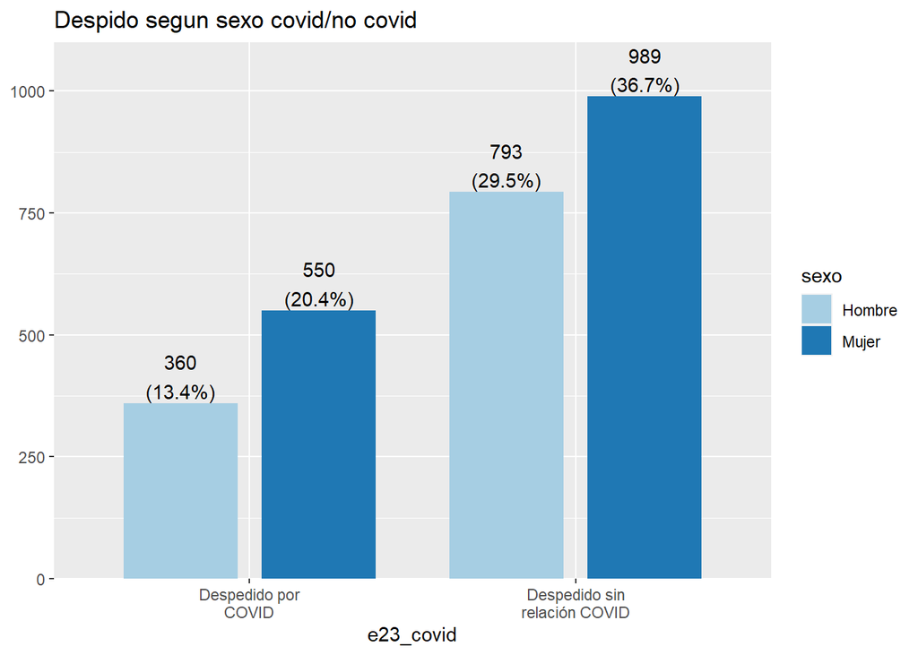

```r
################################################################################
###En las tablas y gráficos anteriores las respuestas contenidas en cada variable###
###calzan con los NA de la otra variable --no se visualizan valores--###

#Motivo Despido según Sexo

plot_grpfrq(JJA_proc$e23_covid, JJA_proc$sexo,
            type = "bar", title = "Despido segun sexo covid/no covid")
```

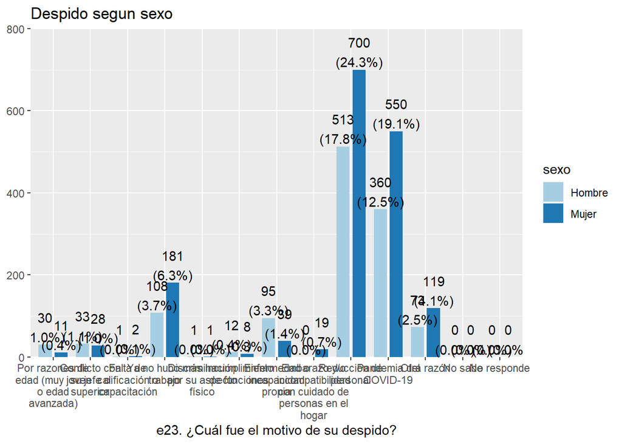

```r
plot_grpfrq(JJA_proc$e23, JJA_proc$sexo,
            type = "bar", title = "Despido segun sexo")
```

```r
sjt.xtab(JJA_proc$sexo, JJA_proc$e23_covid,
         show.col.prc=TRUE,
         show.row.prc=TRUE,
         show.summary=FALSE,
         encoding = "UTF-8",
         title = "Tabla Edad segun Informalidad covid/no covid")
```

| sexo | e23_covid |  | Total |  |
| --- | --- | --- | --- | --- |
|  | Despedido por COVID | Despedido sin relaciÃ³n COVID |  |  |
| Hombre | 360 31.2 % 39.6 % | 793 68.8 % 44.5 % |  | 1153 100 % 42.8 % |
| Mujer | 550 35.7 % 60.4 % | 989 64.3 % 55.5 % | 1539 100 % 57.2 % |  |
| Total | 910 33.8 % 100 % | 1782 66.2 % 100 % | 2692 100 % 100 % |  |

```r
sjt.xtab(JJA_proc$sexo, JJA_proc$e23,
         show.col.prc=TRUE,
         show.row.prc=TRUE,
         show.summary=FALSE,
         encoding = "UTF-8",
         title = "Tabla Edad segun Informalidad")
```

| sexo | e23. ¿Cuál fue el motivo de su despido? |  |  |  |  |  |  |  |  |  |  |  |  | Total |  |
| --- | --- | --- | --- | --- | --- | --- | --- | --- | --- | --- | --- | --- | --- | --- | --- |
|  | Por razones de edad (muy joven o edad avanzada) | Conflicto con su jefe o superior | Falta de calificación o capacitación | Ya no hubo más trabajo | Discriminación por su aspecto físico | Incumplimiento de funciones | Enfermedad o incapacidad propia | Embarazo y/o incompatibilidad con cuidado de personas en el hogar | Reducción de personal | Pandemia del COVID-19 | Otra razón | No sabe | No responde |  |  |
| Hombre | 30 2.4 % 73.2 % | 33 2.7 % 54.1 % | 1 0.1 % 33.3 % | 108 8.8 % 37.4 % | 1 0.1 % 50 % | 12 1 % 60 % | 95 7.7 % 70.9 % | 0 0 % 0 % | 513 41.8 % 42.3 % | 360 29.4 % 39.6 % | 73 6 % 38 % | 0 0 % 0 % | 0 0 % 0 % |  | 1226 100 % 42.5 % |
| Mujer | 11 0.7 % 26.8 % | 28 1.7 % 45.9 % | 2 0.1 % 66.7 % | 181 10.9 % 62.6 % | 1 0.1 % 50 % | 8 0.5 % 40 % | 39 2.4 % 29.1 % | 19 1.1 % 100 % | 700 42.2 % 57.7 % | 550 33.2 % 60.4 % | 119 7.2 % 62 % | 0 0 % 0 % | 0 0 % 0 % | 1658 100 % 57.5 % |  |
| Total | 41 1.4 % 100 % | 61 2.1 % 100 % | 3 0.1 % 100 % | 289 10 % 100 % | 2 0.1 % 100 % | 20 0.7 % 100 % | 134 4.6 % 100 % | 19 0.7 % 100 % | 1213 42.1 % 100 % | 910 31.6 % 100 % | 192 6.7 % 100 % | 0 0 % 100 % | 0 0 % 100 % | 2884 100 % 100 % |  |

Al analizar la graficas bivariadas, sorprenden dos graficas especificas. La primera es las diferencias por sexo en las condiciones de actividad. Sobre todo las diferencias entre hombres y mujeres fuera de la fuerza de trabajo, que alcanza un 15.8%. La segunda grafica a describir es el cruce entre sexo y razón de despido. Sorprende la diferencia de despidos entre hombres y mujeres, en ambos casos las mujeres fueron más despedidas que los hombres.